# Deep Learning Examples

Deep Learning

Neural Networks

NLP

R

Four Keras examples: circle classification illustrating nonlinear decision boundaries, Zagat restaurant price prediction, Airbnb listing classification, and IMDB sentiment analysis.

Author

Nick Polson and Vadim Sokolov

```r
library(ggplot2)
```

## Circle Classification

A neural network needs at least four hyperplanes to separate two concentric classes, illustrating how depth enables nonlinear boundaries.

### Data Generation

One hundred points are drawn uniformly inside a circle of radius 4 (class 0) and one hundred between radii 8 and 10 (class 1).

```r
set.seed(42)
n <- 100

r_inner <- sqrt(runif(n)) * 4
theta_inner <- runif(n, 0, 2 * pi)
x_inner <- cbind(r_inner * cos(theta_inner), r_inner * sin(theta_inner))

r_outer <- sqrt(runif(n, 64, 100))
theta_outer <- runif(n, 0, 2 * pi)
x_outer <- cbind(r_outer * cos(theta_outer), r_outer * sin(theta_outer))

X <- rbind(x_inner, x_outer)
y <- c(rep(0, n), rep(1, n))
```

### Feature Engineering with Sigmoid

A sigmoid feature $\sigma(w^\top x - b)$ defines one curved boundary. Four such features can form a closed region.

```r
sigmoid <- function(z) 1 / (1 + exp(-z))

feature <- function(x, w, b) sigmoid(x %*% w - b)
```

### Grid Visualization

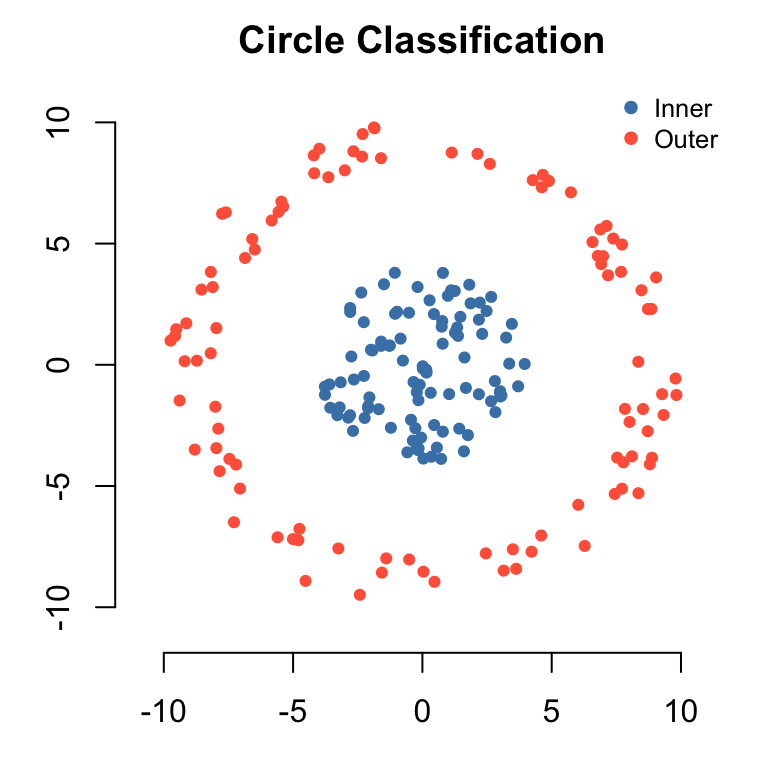

```r
par(bty = "n", mar = c(3, 3, 2, 1))
plot(X[y == 0, 1], X[y == 0, 2],
     col = "steelblue", pch = 19, cex = 0.7,
     xlim = c(-11, 11), ylim = c(-11, 11),
     xlab = "x1", ylab = "x2",
     main = "Circle Classification")
points(X[y == 1, 1], X[y == 1, 2],
       col = "tomato", pch = 19, cex = 0.7)
legend("topright", legend = c("Inner", "Outer"),
       col = c("steelblue", "tomato"), pch = 19, bty = "n", cex = 0.8)
```

### Keras Model

```r
model_circle <- keras_model_sequential() |>
  layer_dense(units = 8, activation = "relu", input_shape = 2) |>
  layer_dense(units = 8, activation = "relu") |>
  layer_dense(units = 1, activation = "sigmoid")

model_circle |> compile(
  optimizer = "adam",
  loss      = "binary_crossentropy",
  metrics   = "accuracy"
)

history_circle <- model_circle |> fit(
  X, y,
  epochs     = 100,
  batch_size = 32,
  validation_split = 0.2,
  verbose    = 0
)
```

### Decision Boundary

```r
grid_seq <- seq(-11, 11, length.out = 80)
grid_pts <- expand.grid(x1 = grid_seq, x2 = grid_seq)
grid_mat <- as.matrix(grid_pts)
probs    <- predict(model_circle, grid_mat, verbose = 0)
z_mat    <- matrix(probs, nrow = 80, ncol = 80)

par(bty = "n", mar = c(3, 3, 2, 1))
image(grid_seq, grid_seq, z_mat,
      col  = colorRampPalette(c("lightblue", "lightyellow", "lightsalmon"))(50),
      xlab = "x1", ylab = "x2",
      main = "Decision Boundary")
contour(grid_seq, grid_seq, z_mat, levels = 0.5,
        add = TRUE, col = "black", lwd = 1.5)
points(X[y == 0, 1], X[y == 0, 2], col = "steelblue", pch = 19, cex = 0.5)
points(X[y == 1, 1], X[y == 1, 2], col = "tomato",    pch = 19, cex = 0.5)
```

[output not shown]

## Zagat Restaurant Prices

The Zagat dataset contains 114 New York City restaurants with food, decor, and service ratings alongside price per person. We compare a linear regression baseline to a small fully-connected network.

### Data

```r
zagat <- read.csv("zagat.csv")
summary(zagat[, c("food", "decor", "service", "price")])
```

[output not shown]

```r
round(cor(zagat[, c("food", "decor", "service", "price")]), 3)
```

[output not shown]

### Scatter Plots

```r
par(mfrow = c(1, 3), bty = "n", mar = c(4, 4, 2, 1))
plot(zagat$food,    zagat$price, pch = 19, cex = 0.7,
     col = "steelblue", xlab = "Food",    ylab = "Price")
plot(zagat$decor,   zagat$price, pch = 19, cex = 0.7,
     col = "steelblue", xlab = "Decor",   ylab = "")
plot(zagat$service, zagat$price, pch = 19, cex = 0.7,
     col = "steelblue", xlab = "Service", ylab = "")
```

[output not shown]

### Linear Regression

```r
lm_zagat <- lm(price ~ food + decor + service, data = zagat)
summary(lm_zagat)
```

[output not shown]

### Deep Learning Model

```r
X_zagat <- as.matrix(zagat[, c("food", "decor", "service")])
y_zagat <- zagat$price

model_zagat <- keras_model_sequential() |>
  layer_dense(units = 64, activation = "relu", input_shape = 3) |>
  layer_dense(units = 64, activation = "relu") |>
  layer_dense(units = 32, activation = "relu") |>
  layer_dense(units = 1)

model_zagat |> compile(
  optimizer = optimizer_rmsprop(),
  loss      = "mse"
)

model_zagat |> fit(
  X_zagat, y_zagat,
  epochs     = 200,
  batch_size = 16,
  verbose    = 0
)
```

### Comparison: Fitted vs. Actual

```r
fitted_lm <- fitted(lm_zagat)
fitted_dl <- as.vector(predict(model_zagat, X_zagat, verbose = 0))

par(mfrow = c(1, 2), bty = "n", mar = c(4, 4, 2, 1))

plot(y_zagat, fitted_lm, pch = 19, cex = 0.7, col = "steelblue",
     xlab = "Actual", ylab = "Fitted", main = "OLS")
abline(0, 1, col = "gray50", lty = 2)

plot(y_zagat, fitted_dl, pch = 19, cex = 0.7, col = "tomato",
     xlab = "Actual", ylab = "Fitted", main = "Deep Learning")
abline(0, 1, col = "gray50", lty = 2)
```

[output not shown]

## Airbnb Classification

A larger classification task: predict one of 12 Airbnb listing categories from 661 listing features, using 4,999 observations. Data files `X5k.txt` and `Y5k.txt` are required externally.

### Data

```r
X_airbnb <- as.matrix(read.table("X5k.txt"))
y_raw    <- as.matrix(read.table("Y5k.txt"))

n_classes <- length(unique(y_raw))
y_airbnb  <- to_categorical(y_raw - 1, num_classes = n_classes)

cat("Features:", ncol(X_airbnb), " Classes:", n_classes,
    " Observations:", nrow(X_airbnb), "\n")
```

[output not shown]

### Model

The architecture uses dropout for regularization between dense layers.

```r
model_airbnb <- keras_model_sequential() |>
  layer_dense(units = 64, activation = "relu", input_shape = ncol(X_airbnb)) |>
  layer_dropout(rate = 0.4) |>
  layer_dense(units = 64, activation = "relu") |>
  layer_dropout(rate = 0.3) |>
  layer_dense(units = n_classes, activation = "softmax")

model_airbnb |> compile(
  optimizer = optimizer_rmsprop(),
  loss      = "categorical_crossentropy",
  metrics   = "accuracy"
)

model_airbnb |> fit(
  X_airbnb, y_airbnb,
  epochs           = 20,
  batch_size       = 64,
  validation_split = 0.2,
  verbose          = 1
)
```

## IMDB Sentiment Classification

Binary sentiment classification on 25,000 movie reviews. Each review is encoded as a sequence of word indices; we use a bag-of-words representation (binary term presence) with a vocabulary of 10,000 words.

### Data Preparation

```r
imdb <- dataset_imdb(num_words = 10000)

x_train_raw <- imdb$train$x
y_train      <- imdb$train$y
x_test_raw   <- imdb$test$x
y_test       <- imdb$test$y

vectorize_sequences <- function(sequences, dimension = 10000) {
  results <- matrix(0, nrow = length(sequences), ncol = dimension)
  for (i in seq_along(sequences)) {
    results[i, sequences[[i]]] <- 1
  }
  results
}

x_train <- vectorize_sequences(x_train_raw)
x_test  <- vectorize_sequences(x_test_raw)
```

Each review becomes a binary vector of length 10,000: entry $j$ is 1 if word $j$ appeared in the review, 0 otherwise.

### Model

```r
model_imdb <- keras_model_sequential() |>
  layer_dense(units = 16, activation = "relu", input_shape = 10000) |>
  layer_dense(units = 16, activation = "relu") |>
  layer_dense(units = 1,  activation = "sigmoid")

model_imdb |> compile(
  optimizer = optimizer_rmsprop(),
  loss      = "binary_crossentropy",
  metrics   = "accuracy"
)
```

Two hidden layers of 16 units with ReLU activation followed by a sigmoid output for binary classification. Binary crossentropy is the appropriate loss for a two-class probability output.

### Training with Validation

```r
x_val   <- x_train[1:10000, ]
x_train_partial <- x_train[10001:25000, ]
y_val   <- y_train[1:10000]
y_train_partial  <- y_train[10001:25000]

history_imdb <- model_imdb |> fit(
  x_train_partial, y_train_partial,
  epochs           = 20,
  batch_size       = 512,
  validation_data  = list(x_val, y_val),
  verbose          = 0
)
```

### Training History

```r
hist_df <- data.frame(
  epoch        = seq_len(length(history_imdb$metrics$loss)),
  train_loss   = history_imdb$metrics$loss,
  val_loss     = history_imdb$metrics$val_loss,
  train_acc    = history_imdb$metrics$accuracy,
  val_acc      = history_imdb$metrics$val_accuracy
)

par(mfrow = c(1, 2), bty = "n", mar = c(4, 4, 2, 1))

plot(hist_df$epoch, hist_df$train_loss,
     type = "l", col = "steelblue", lwd = 1.5,
     xlab = "Epoch", ylab = "Loss", main = "Loss",
     ylim = range(c(hist_df$train_loss, hist_df$val_loss)))
lines(hist_df$epoch, hist_df$val_loss,
      col = "tomato", lwd = 1.5, lty = 2)
legend("topright", legend = c("Train", "Validation"),
       col = c("steelblue", "tomato"), lty = c(1, 2),
       lwd = 1.5, bty = "n", cex = 0.8)

plot(hist_df$epoch, hist_df$train_acc,
     type = "l", col = "steelblue", lwd = 1.5,
     xlab = "Epoch", ylab = "Accuracy", main = "Accuracy",
     ylim = range(c(hist_df$train_acc, hist_df$val_acc)))
lines(hist_df$epoch, hist_df$val_acc,
      col = "tomato", lwd = 1.5, lty = 2)
legend("bottomright", legend = c("Train", "Validation"),
       col = c("steelblue", "tomato"), lty = c(1, 2),
       lwd = 1.5, bty = "n", cex = 0.8)
```

[output not shown]

### Test Evaluation

```r
results <- model_imdb |> evaluate(x_test, y_test, verbose = 0)
cat("Test loss:    ", round(results["loss"], 4), "\n")
cat("Test accuracy:", round(results["accuracy"], 4), "\n")
```

[output not shown]